# Choice Task Regression Analysis

## Visualize choice variance

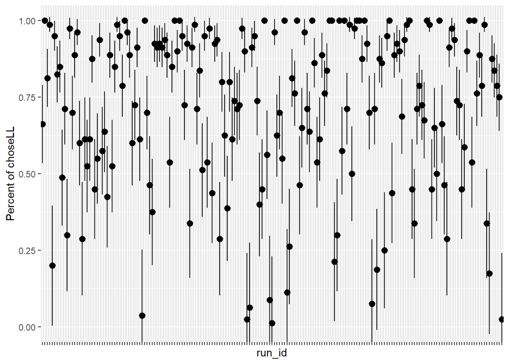

```r
data_plot = grouped_n_ET %>%
    filter(choseLL==1) %>%
    mutate(SE = sqrt(choice_perc * (1-choice_perc)/n))

ggplot(data_plot, aes(factor(run_id), choice_perc)) +
    geom_pointrange(aes(ymin=choice_perc-1.96*SE,
                        ymax=choice_perc+1.96*SE)) +
    xlab('run_id') +
    ylab('Percent of choseLL') +
    theme(
        axis.text.x = element_blank(),
        ) +
    coord_cartesian(ylim=c(0, 1))
```

```r
dir.create(file.path(path_results, 'MLA'))
ggsave(file.path(path_results, 'MLA', 'runs_vs_choice.pdf'),
       width=5.5, height=5)
```

# Cleaning

```r
# Data on subject level

exclude_runs = c(
    # exclude_runs,
    runs_biasedChoices,
    runs_na_oi,
    runs_na_ai,
    runs_na_pi) %>%
    sort() %>%
    unique()

grouped = data.frame(
    source =     c(
        'runs_biasedChoices',
        'runs_na_oi',
        'runs_na_ai',
        'runs_na_pi',
        'total'),
    n = c(
        length(runs_biasedChoices),
        length(runs_na_oi),
        length(runs_na_ai),
        length(runs_na_pi),
        length(exclude_runs)
    )
)
grouped
```

```
##               source  n
## 1 runs_biasedChoices 30
## 2         runs_na_oi 20
## 3         runs_na_ai 20
## 4         runs_na_pi 27
## 5              total 51
```

```r
data_subject = remove_runs(data_subject)
```

```
## [1] "Remove missing et indices:"
## [1] "data_subject"
## [1] "length raw:  185"
## [1] "length cleaned:  134"
```

```r
data_trial = remove_runs(data_trial)
```

```
## [1] "Remove missing et indices:"
## [1] "data_trial"
## [1] "length raw:  14758"
## [1] "length cleaned:  10685"
```

```r
data_subject = remove_na_et_indices(data_subject)
```

```
## [1] "data_subject"
## [1] "Raw:  134"
## [1] "Cleaned:  134"
```

```r
data_trial = remove_na_et_indices(data_trial)
```

```
## [1] "data_trial"
## [1] "Raw:  10685"
## [1] "Cleaned:  7884"
```

# Correlative Analysis

## Scatter matrix

```r
dir.create(file.path(path_results, 'correlations'))
```

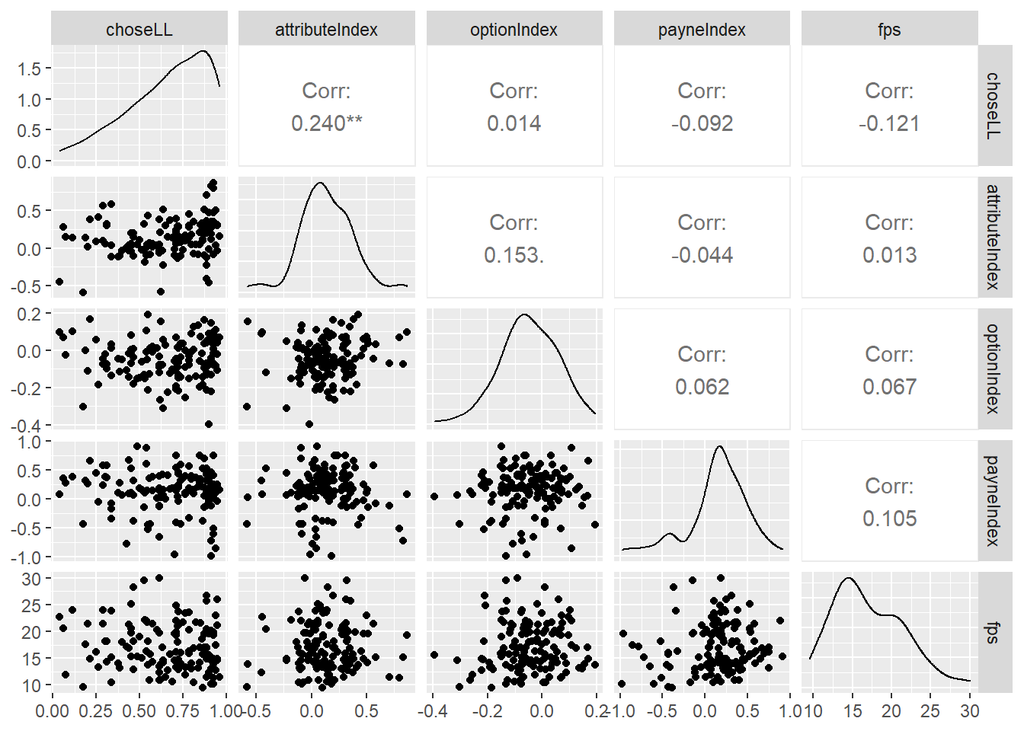

```r
ggpairs(
    data_subject %>% dplyr::select(
        choseLL,
        attributeIndex, optionIndex, payneIndex, fps),
    progress = F)
```

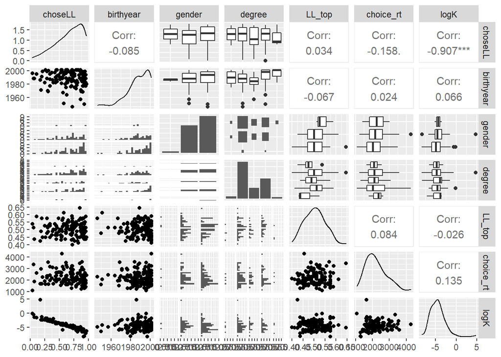

```r
ggsave(file.path(path_results, 'correlations', 'corr_plot_1.pdf'),
       width=5.5, height=5)

ggpairs(
    data_subject %>% dplyr::select(
        choseLL, birthyear, gender, degree,
        LL_top, choice_rt, logK),
    progress = F)
```

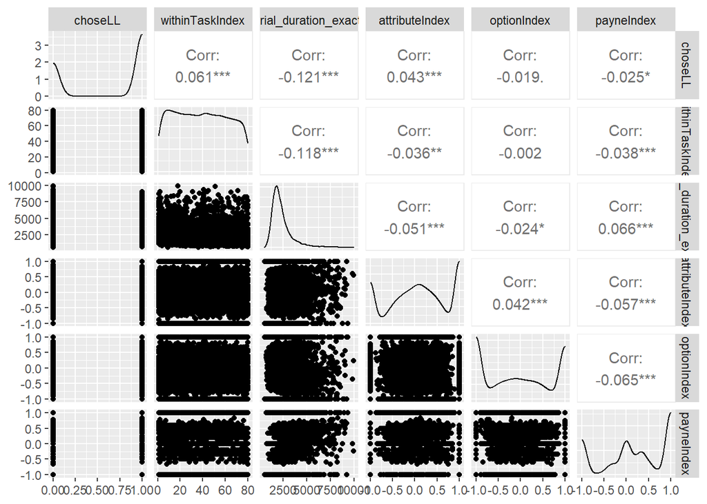

```r
ggsave(file.path(path_results, 'correlations', 'corr_plot_2.pdf'),
       width=5.5, height=5)
ggpairs(
    data_trial %>% dplyr::select(
        choseLL,
        withinTaskIndex, trial_duration_exact,
        attributeIndex, optionIndex, payneIndex),
    progress = F)
```

```r
ggsave(file.path(path_results, 'correlations', 'corr_plot_trial.pdf'),
       width=5.5, height=5)
```

## Check withinTaskIndex and trial_duration_exact

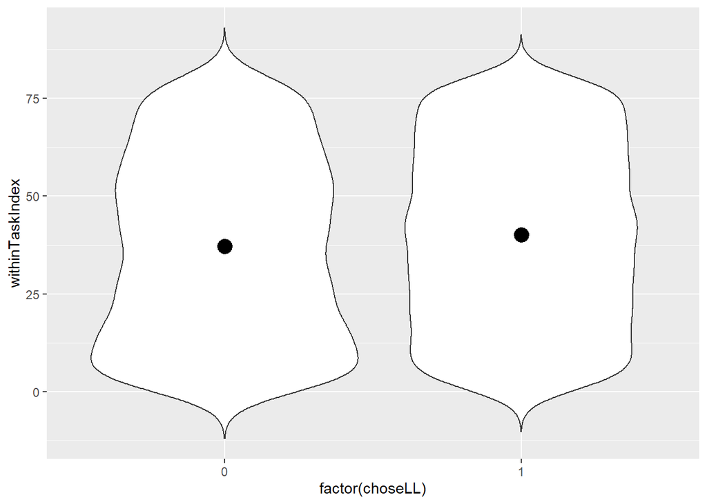

```r
ggplot(data_trial, aes(x=factor(choseLL), y=withinTaskIndex)) +
    geom_violin(trim=FALSE) +
    stat_summary(fun=mean, size=1)
```

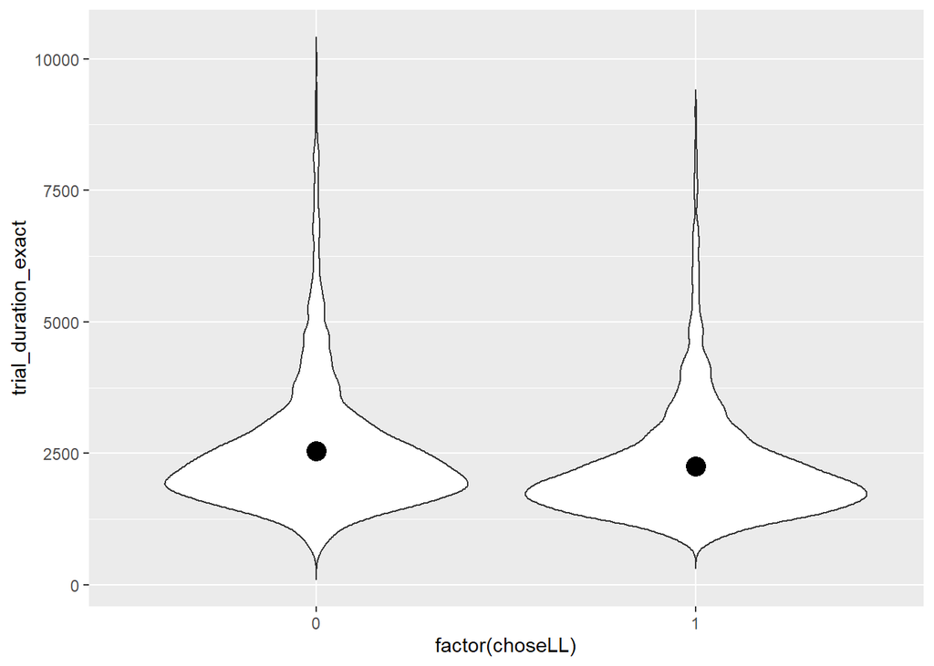

```r
ggplot(data_trial, aes(x=factor(choseLL), y=trial_duration_exact)) +
    geom_violin(trim=FALSE) +
    stat_summary(fun=mean, size=1)
```

# Logistic Regression on subject-level

Sommet, 2017 - choseLL is more likely than choseSS. - Logisitic regression does not have residuals because it predicts probabilities not concrete values. - Predict log-odds (exp(beta)). Odds increase by the factor exp(beta), when the predictor changes in one unit. beta=0 means odds=1. - A positive Attribute Index indicates more fixations on the amount attributes - A negative Option Index indicates more fixations on the delayed option - A negative Payne Index indicates more transitions within attributes